[figure not shown]

**Treball de Final de Màster**

**ANÀLISI DEL DIA MUNDIAL DE LES MALALTIES MINORITÀRIES (Font de dades: TWITTER)**.

# PAC 3: Disseny i Implementació del TFM.

# ANÀLISI

Implementació de l'etapa d'exploració inicial i analisi estructural de la base de dades de tuits.  
En aquest Jupyter Notebook, s'apliquen tècniques d'aprenentatge no supervisat implementant la vectorització TF-IDF i els algorismes de clustering.

```python
import time
import math
import string
import re
import pickle
import collections
from datetime import datetime
import numpy as np
import pandas as pd
from nltk.stem import LancasterStemmer
from nltk.cluster.util import cosine_distance
from nltk.cluster import KMeansClusterer
from sklearn.base import BaseEstimator, TransformerMixin
from nltk.tokenize import TweetTokenizer
from nltk import everygrams
from nltk.corpus import stopwords
from sklearn.feature_extraction.text import CountVectorizer, TfidfVectorizer
from sklearn.pipeline import Pipeline
import matplotlib.pyplot as plt
import delayedsparse
import scipy.sparse
from sklearn.decomposition import PCA
import seaborn as sb
import logging
from sklearn.metrics import silhouette_score
from sklearn.cluster import KMeans
from sklearn import preprocessing
from sklearn.metrics.pairwise import cosine_similarity
```

```python
# Lectura del dataset generat per modelitzar
df=pd.read_excel("C:/Users/qdeda/TFM_Code/DMMM_dataset_Final.xlsx")
```

```python
# Llegim els tuits depurats. I generem una llista
# de documents amb el text de cada tuit.
tuits = list(df.text_net)
```

```python
tuits[0:5]
```

```
['winning works photographic contest form travelling exhibition tour geography espa',
 'afternoon starting new centered',
 'thanks emilio butragueño david de maria soledad giménez commitment thang thang',
 'going look beautiful',
 'honor collaborating teaching subject physiopathology']
```

```python
index_list=[]
for row in df.iterrows():
    index_list.append(pd.to_datetime(row[1]['created_at'], format='%a %b %d %H:%M:%S +0000 %Y'))
df.index = index_list
```

```python
tuits=df[['_id','text_net','text_Norm','user_idstr','polarity','subjectivity']]
tuits.columns=['_id','text', 'text_norm','autor','polarity','subjectivity']
df=[]
```

```python
tuits.head(3)
```

|  | _id | text | text_norm | autor | polarity | subjectivity |
| --- | --- | --- | --- | --- | --- | --- |
| 2020-02-13 09:58:19 | 5e78e80f4e54db2148d19749 | winning works photographic contest form travel... | win work photograph contest form travel exhibi... | 4054806561 | 0.500000 | 0.750000 |
| 2020-02-13 10:01:01 | 5e78e80f4e54db2148d1974a | afternoon starting new centered | afternoon start new cent | 64270216 | 0.068182 | 0.277273 |
| 2020-02-13 10:01:31 | 5e78e80f4e54db2148d1974b | thanks emilio butragueño david de maria soleda... | thank emilio butragueño david de mar soledad g... | 233031604 | 0.200000 | 0.200000 |

Podem observar els dies on s'han celebrat events o bé obert temes de debat amb més participació. La major participació pertany al dia **29 de febrer**, on el màxim nombre de tuits és proper als 140 tuits en un minut, i això succeeix a partir de les 09:00h. El pic màxim de tot el dia es produeix entre les 14:00h i 15:00h, però en totes les hores és mantenen aquests valors en algun minut.

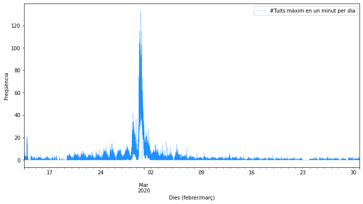

```python
# Gràfica del nombre de tuits per minut en cada dia
tuits[['text']].resample('T').count().rename(columns=dict(text='#Tuits màxim en un minut per dia')). \
plot(figsize=(12,6),linewidth=0.3,c='dodgerblue')
plt.xlabel("Dies (febrer/març)")
plt.ylabel("Freqüència")
plt.savefig("analisi1_tuitsMIN_DIA.jpg",format='jpg',bbox_inches='tight')
```

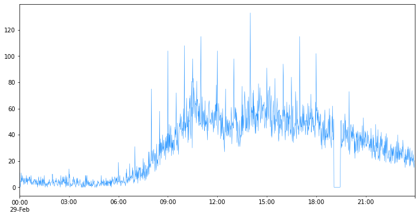

```python
a=tuits[tuits.index>datetime.strptime("29/02/2020","%d/%m/%Y")]
b=a[a.index<datetime.strptime("01/03/2020","%d/%m/%Y")]. \
resample('T').count()['text'].plot(figsize=(12,6),linewidth=0.5,c='dodgerblue')
plt.savefig("analisi2_tuitsMIN_DIA_detall_dia29.jpg",format='jpg',bbox_inches='tight')
```

Ampliem el mostreig a hores, observem què el nombre de tuits màxim per dia arriba a assolir-se també el dia mundial de les malalties minoritàries, en la mateixa franja horaria i és de 3530 tuits.

```python
# nombre màxim de tuits per hora assolits el dia 29/02/2020
tuits[['text']].resample('H').count().max()
```

```
text    3530
dtype: int64
```

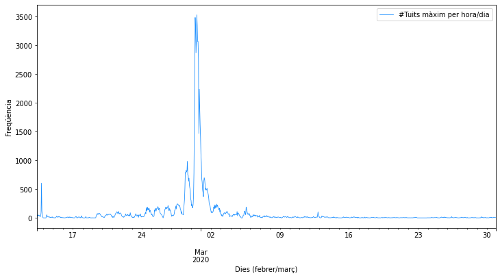

```python
# Gràfica del nombre de tuits per minut en cada dia
tuits[['text']].resample('H').count().rename(columns=dict(text='#Tuits màxim per hora/dia')). \
plot(figsize=(12,6),linewidth=0.8,c='dodgerblue')
plt.xlabel("Dies (febrer/març)")
plt.ylabel("Freqüència")
plt.savefig("analisi3_tuits_HORA_DIA.jpg",format='jpg',bbox_inches='tight')
```

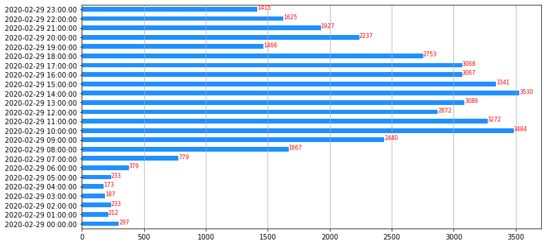

```python
a=tuits[tuits.index>datetime.strptime("29/02/2020","%d/%m/%Y")]
b=a[a.index<datetime.strptime("01/03/2020","%d/%m/%Y")]
c=b.resample('H').count()['text']
b.resample('H').count()['text'].plot(figsize=(12,6),linewidth=0.8, kind='barh',color='dodgerblue').grid(True,'major','x')
for index, value in enumerate(c):
    plt.text(value, index, str(value),None,fontsize=8,color='red')
plt.savefig("analisi4_tuits_barres_dia29_etiq.jpg",format='jpg',bbox_inches='tight')
```

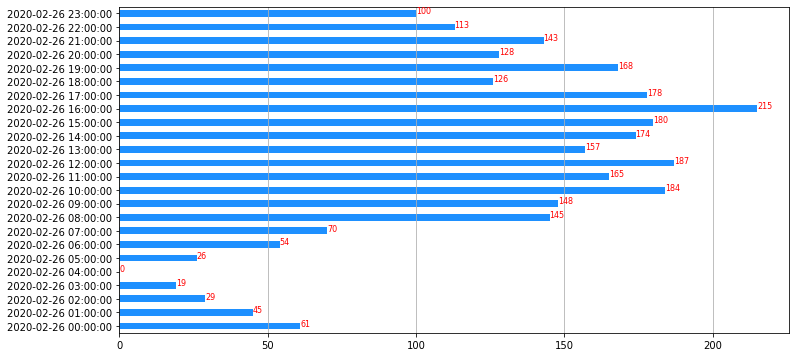

```python
a=tuits[tuits.index>datetime.strptime("26/02/2020","%d/%m/%Y")]
b=a[a.index<datetime.strptime("27/02/2020","%d/%m/%Y")]
c=b.resample('H').count()['text']
b.resample('H').count()['text'].plot(figsize=(12,6),linewidth=0.8, kind='barh',color='dodgerblue').grid(True,'major','x')
for index, value in enumerate(c):
    plt.text(value, index, str(value),None,fontsize=8,color='red')
plt.savefig("analisi5_tuits_barres_dia26_etiq.jpg",format='jpg',bbox_inches='tight')
```

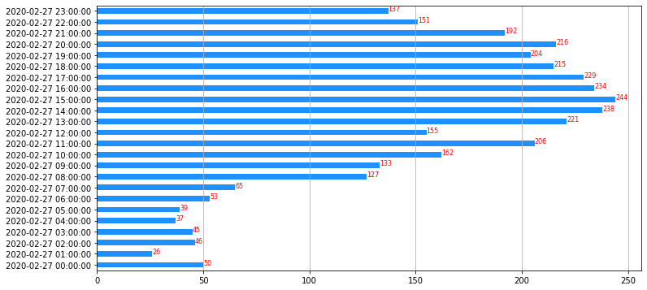

```python
a=tuits[tuits.index>datetime.strptime("27/02/2020","%d/%m/%Y")]
b=a[a.index<datetime.strptime("28/02/2020","%d/%m/%Y")]
c=b.resample('H').count()['text']
b.resample('H').count()['text'].plot(figsize=(12,6),linewidth=0.8, kind='barh',color='dodgerblue').grid(True,'major','x')
for index, value in enumerate(c):
    plt.text(value, index, str(value),None,fontsize=8,color='red')
plt.savefig("analisi6_tuits_barres_dia27_etiq.jpg",format='jpg',bbox_inches='tight')
```

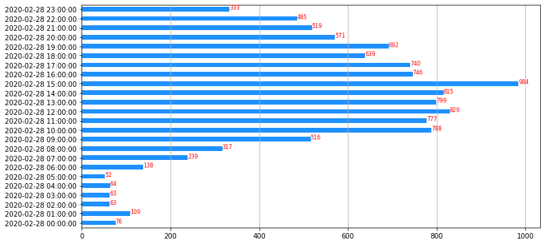

```python
a=tuits[tuits.index>datetime.strptime("28/02/2020","%d/%m/%Y")]
b=a[a.index<datetime.strptime("29/02/2020","%d/%m/%Y")]
c=b.resample('H').count()['text']
b.resample('H').count()['text'].plot(figsize=(12,6),linewidth=0.8, kind='barh',color='dodgerblue').grid(True,'major','x')
for index, value in enumerate(c):
    plt.text(value, index, str(value),None,fontsize=8,color='red')
plt.savefig("analisi7_tuits_barres_dia28_etiq.jpg",format='jpg',bbox_inches='tight')
```

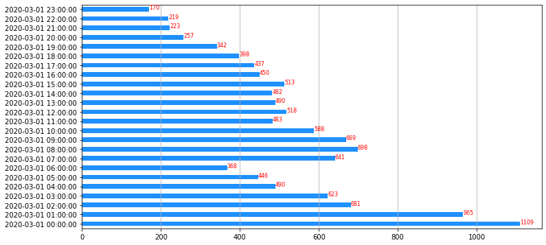

```python
a=tuits[tuits.index>datetime.strptime("01/03/2020","%d/%m/%Y")]
b=a[a.index<datetime.strptime("02/03/2020","%d/%m/%Y")]
c=b.resample('H').count()['text']
b.resample('H').count()['text'].plot(figsize=(12,6),linewidth=0.8, kind='barh',color='dodgerblue').grid(True,'major','x')
for index, value in enumerate(c):
    plt.text(value, index, str(value),None,fontsize=8,color='red')
plt.savefig("analisi8_tuits_barres_dia01_etiq.jpg",format='jpg',bbox_inches='tight')
```

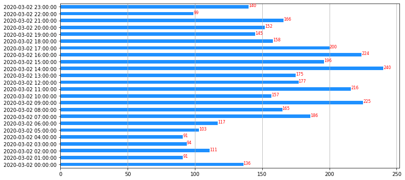

```python
a=tuits[tuits.index>datetime.strptime("02/03/2020","%d/%m/%Y")]
b=a[a.index<datetime.strptime("03/03/2020","%d/%m/%Y")]
c=b.resample('H').count()['text']
b.resample('H').count()['text'].plot(figsize=(12,6),linewidth=0.8, kind='barh',color='dodgerblue').grid(True,'major','x')
for index, value in enumerate(c):
    plt.text(value, index, str(value),None,fontsize=8,color='red')
plt.savefig("analisi9_tuits_barres_dia02_etiq.jpg",format='jpg',bbox_inches='tight')
```

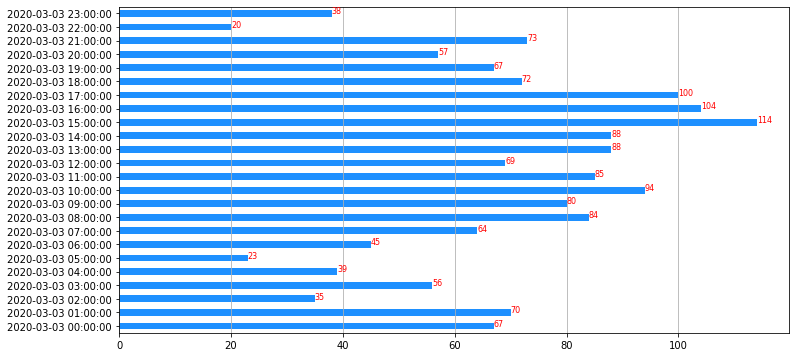

```python
a=tuits[tuits.index>datetime.strptime("03/03/2020","%d/%m/%Y")]
b=a[a.index<datetime.strptime("04/03/2020","%d/%m/%Y")]
c=b.resample('H').count()['text']
b.resample('H').count()['text'].plot(figsize=(12,6),linewidth=0.8, kind='barh',color='dodgerblue').grid(True,'major','x')
for index, value in enumerate(c):
    plt.text(value, index, str(value),None,fontsize=8,color='red')
plt.savefig("analisi10_tuits_barres_dia03_etiq.jpg",format='jpg',bbox_inches='tight')
```

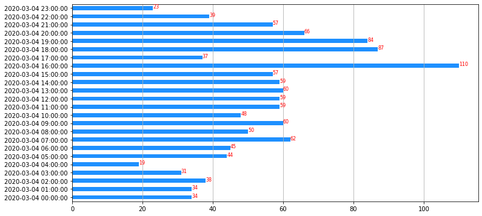

```python
a=tuits[tuits.index>datetime.strptime("04/03/2020","%d/%m/%Y")]
b=a[a.index<datetime.strptime("05/03/2020","%d/%m/%Y")]
c=b.resample('H').count()['text']
b.resample('H').count()['text'].plot(figsize=(12,6),linewidth=0.8, kind='barh',color='dodgerblue').grid(True,'major','x')
for index, value in enumerate(c):
    plt.text(value, index, str(value),None,fontsize=8,color='red')
plt.savefig("analisi11_tuits_barres_dia04_etiq.jpg",format='jpg',bbox_inches='tight')
```

```python
a=tuits[tuits.index>datetime.strptime("18/02/2020","%d/%m/%Y")]
b=a[a.index<datetime.strptime("19/02/2020","%d/%m/%Y")]
Dia1802=b.resample('H').count()['text']
Dia1802=pd.DataFrame({'grup':"2020_02_18", 'tuits':Dia1802})

a=tuits[tuits.index>datetime.strptime("27/02/2020","%d/%m/%Y")]
b=a[a.index<datetime.strptime("28/02/2020","%d/%m/%Y")]
Dia27=b.resample('H').count()['text']
Dia27=pd.DataFrame({'grup':"2020_02_27", 'tuits':Dia27})

a=tuits[tuits.index>datetime.strptime("28/02/2020","%d/%m/%Y")]
b=a[a.index<datetime.strptime("29/02/2020","%d/%m/%Y")]
Dia28=b.resample('H').count()['text']
Dia28=pd.DataFrame({'grup':"2020_02_28", 'tuits':Dia28})

a=tuits[tuits.index>datetime.strptime("29/02/2020","%d/%m/%Y")]
b=a[a.index<datetime.strptime("01/03/2020","%d/%m/%Y")]
Dia29=b.resample('H').count()['text']
Dia29=pd.DataFrame({'grup':"2020_02_29", 'tuits':Dia29})

a=tuits[tuits.index>datetime.strptime("01/03/2020","%d/%m/%Y")]
b=a[a.index<datetime.strptime("02/03/2020","%d/%m/%Y")]
Dia01=b.resample('H').count()['text']
Dia01=pd.DataFrame({'grup':"2020_03_01", 'tuits':Dia01})

a=tuits[tuits.index>datetime.strptime("02/03/2020","%d/%m/%Y")]
b=a[a.index<datetime.strptime("03/03/2020","%d/%m/%Y")]
Dia02=b.resample('H').count()['text']
Dia02=pd.DataFrame({'grup':"2020_03_02", 'tuits':Dia02})

a=tuits[tuits.index>datetime.strptime("03/03/2020","%d/%m/%Y")]
b=a[a.index<datetime.strptime("04/03/2020","%d/%m/%Y")]
Dia03=b.resample('H').count()['text']
Dia03=pd.DataFrame({'grup':"2020_03_03", 'tuits':Dia03})

a=tuits[tuits.index>datetime.strptime("04/03/2020","%d/%m/%Y")]
b=a[a.index<datetime.strptime("05/03/2020","%d/%m/%Y")]
Dia04=b.resample('H').count()['text']
Dia04=pd.DataFrame({'grup':"2020_03_04", 'tuits':Dia04})

a=tuits[tuits.index>datetime.strptime("18/03/2020","%d/%m/%Y")]
b=a[a.index<datetime.strptime("19/03/2020","%d/%m/%Y")]
Dia1803=b.resample('H').count()['text']
Dia1803=pd.DataFrame({'grup':"2020_03_18", 'tuits':Dia1803})
```

```python
dfDies=[]
dfDies=Dia1802.append([Dia27,Dia28,Dia29,Dia01,Dia02,Dia03,Dia04,Dia1803],ignore_index=True)
```

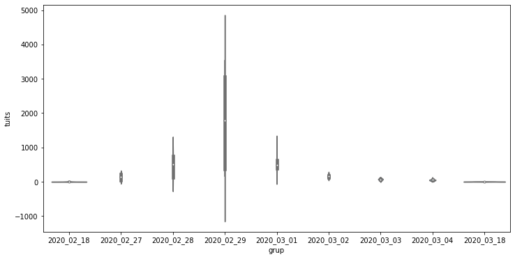

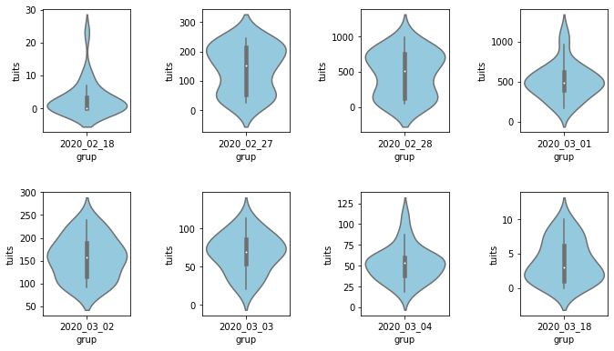

```python
fig, axes = plt.subplots(nrows=1, ncols=1, figsize=(12, 6))
sb.violinplot(x="grup", y="tuits", data=dfDies, ax=axes, color="skyblue")
plt.savefig("analisi12_violins0.jpg",format='jpg',bbox_inches='tight')
fig, axes = plt.subplots(nrows=2, ncols=4, figsize=(10, 6))
sb.violinplot(x="grup", y="tuits", data=dfDies[dfDies.grup.isin(["2020_02_18"])], ax=axes[0][0], color="skyblue")
sb.violinplot(x="grup", y="tuits", data=dfDies[dfDies.grup.isin(["2020_02_27"])], ax=axes[0][1], color="skyblue")
sb.violinplot(x="grup", y="tuits", data=dfDies[dfDies.grup.isin(["2020_02_28"])], ax=axes[0][2], color="skyblue")
sb.violinplot(x="grup", y="tuits", data=dfDies[dfDies.grup.isin(["2020_03_01"])], ax=axes[0][3], color="skyblue")
sb.violinplot(x="grup", y="tuits", data=dfDies[dfDies.grup.isin(["2020_03_02"])], ax=axes[1][0], color="skyblue")
sb.violinplot(x="grup", y="tuits", data=dfDies[dfDies.grup.isin(["2020_03_03"])], ax=axes[1][1], color="skyblue")
sb.violinplot(x="grup", y="tuits", data=dfDies[dfDies.grup.isin(["2020_03_04"])], ax=axes[1][2], color="skyblue")
sb.violinplot(x="grup", y="tuits", data=dfDies[dfDies.grup.isin(["2020_03_18"])], ax=axes[1][3], color="skyblue")
fig.tight_layout(pad=3.0)
plt.savefig("analisi12_violins1.jpg",format='jpg',bbox_inches='tight')
```

```python
def cercar_tokens(tlist):
   # Cerquem tokens d'entre el corpus de tuits.
    text_tuits = ' '.join((t for t in tlist))
    # Usem TweetTokenizer de la llibreria nltk
    # reduce_len redueix cadenes de text repetides a 3 repeticions.
    tokens = (TweetTokenizer(preserve_case=False,
                            reduce_len=True,
                            strip_handles=False)
              .tokenize(text_tuits))
    # Treim puntuacio per si queda algun simbol
    # tot i que el text hauria d'estar ja netejat.
    tokens = [tok for tok in tokens if not tok in string.punctuation]
    return tokens
```

```python
tokens=cercar_tokens(tuits['text'])
print('# total de tokens: {}'.format(len(tokens)))
```

```
# total de tokens: 873224
```

Per conèixer les associaons entre paraules trobem els ngrams fent servir la funció **everygrams** de nltk: Aquesta funció retorna tots els ngrams possibles generats a partir d'una seqüència d'elements.

```python
n_grams = collections.Counter(everygrams(tokens, min_len=2, max_len=4))
# Extreiem les 4 posicions inicials per ser paraules: Rare, Disease, Day, World
print(len(n_grams))
n_grams.most_common(25)[4:]
```

```
927585
```

```
[(('million', 'people'), 4285),
 (('rare', 'disease', 'day'), 4175),
 (('raise', 'awareness'), 3410),
 (('brothers', 'sisters'), 2997),
 (('today', 'day'), 2940),
 (('us', 'opportunity'), 2936),
 (('care', 'brothers'), 2929),
 (('care', 'brothers', 'sisters'), 2928),
 (('offers', 'us'), 2926),
 (('offers', 'us', 'opportunity'), 2926),
 (('opportunity', 'together'), 2925),
 (('together', 'care'), 2925),
 (('sisters', 'ill'), 2925),
 (('us', 'opportunity', 'together'), 2925),
 (('opportunity', 'together', 'care'), 2925),
 (('together', 'care', 'brothers'), 2925),
 (('brothers', 'sisters', 'ill'), 2925),
 (('offers', 'us', 'opportunity', 'together'), 2925),
 (('us', 'opportunity', 'together', 'care'), 2925),
 (('opportunity', 'together', 'care', 'brothers'), 2925),
 (('together', 'care', 'brothers', 'sisters'), 2925)]
```

```python
# cerca del mot "aware"
filtre=tuits[tuits.text.str.lower().str.contains("research")]['text']
# look at text only from matching rows
print("# resultats=",filtre.shape[0])
filtre.head(10)
```

```
# resultats= 7948
```

```
2020-02-13 11:16:56    magina paleo center receives researcher franci...
2020-02-13 11:20:37     rare starting point researcher francisco josé es
2020-02-13 11:33:35    rare starting point researcher francisco josé ...
2020-02-13 13:00:31               research currently focused known known
2020-02-13 13:17:07               research currently focused known count
2020-02-13 13:30:33    still without research treated three million p...
2020-02-13 13:32:06    still without research treated three million p...
2020-02-13 14:00:11    concluded resounding success day impact resear...
2020-02-13 14:04:42    aurora berra berra pres explained importance r...
2020-02-13 14:22:03    aurora berra berra pres explained importance r...
Name: text, dtype: object
```

Fins ara hem explorat les dades, hem vist com es distribueixen els tuits entre unes certes hores al dia i en quina quantitat.  
També respecte els dies, què el màxim nombre de tuits es van concentrar el dia 29 de febrer i dies propers, apareixent pics superiors a 300 tuits diaris en dies on segurament s'han organitzat events.  
També coneixem les paraules més utiltizades i amb quines s'ha associat. Si no considerem els mots obvis com enfermatat, rara, dia, mundial, febrer, que son paraules molt freüents però que no ens aporten molta informació obtenim paraules com: **consciència**, **millions de persones**, **oportunitat**, **tots junts**, dintre dels 25 **n-grams** més freqüents.

Apliquem ingenieria d'estructures (en anglès feature engineering), per tal de representar numèricament (vectors) cada instancia o tuit mitjançant els tokens que el conformen. Aquest procés de vectorització l'aplicarem fent servir la tècnica tf-idf (term frecuency inverse document frecuency). D'aquesta manera disposarem d'una matriu que per files reflecteix els tuits i per columnes els tokens de cada tuit. El valor afegir de **tfidf** resideix en aplicar la operació d'escalat al simple conteig de les paraules del tuit. El factor o pes d'escalat utilitzat és el coeficient **idf** que indica la importancia de la paraula o token respecte la resta de documents. Si la paraula que d'un tuit apareix en tota la resta no es considerarà de molta importancia significativa en el tuit, mentre que si apareix al tuit i molt poc en la resta voldrà dir que és una paraula amb moltes probailitats de ser important o clau en el significat del tuit.

```python
tuits.head(3)
```

|  | _id | text | text_norm | autor | polarity | subjectivity |
| --- | --- | --- | --- | --- | --- | --- |
| 2020-02-13 09:58:19 | 5e78e80f4e54db2148d19749 | winning works photographic contest form travel... | win work photograph contest form travel exhibi... | 4054806561 | 0.500000 | 0.750000 |
| 2020-02-13 10:01:01 | 5e78e80f4e54db2148d1974a | afternoon starting new centered | afternoon start new cent | 64270216 | 0.068182 | 0.277273 |
| 2020-02-13 10:01:31 | 5e78e80f4e54db2148d1974b | thanks emilio butragueño david de maria soleda... | thank emilio butragueño david de mar soledad g... | 233031604 | 0.200000 | 0.200000 |

```python
# filtrem aquells tuits amb subjectivitat >0.5
tuit_subj=tuits[tuits.subjectivity>0.5]
tuit_subj.shape
```

```
(43075, 6)
```

```python
# tuits subjectius positivament
tuit_pos=tuit_subj[tuit_subj.polarity>0.7]
print(tuit_pos.shape)
```

```
(2725, 6)
```

```python
# tuits subjectius negativament
tuit_neg=tuit_subj[tuit_subj.polarity<-0.7]
tuit_neg.shape
```

```
(398, 6)
```

```python
tuit_pos.text
```

```
2020-02-13 10:01:38                                 going look beautiful
2020-02-13 10:29:34                                         good morning
2020-02-13 10:49:43                                 going look beautiful
2020-02-13 12:27:09    happy part publicizing solution optimise diagn...
2020-02-13 14:21:50            great initiative we join us we thank team
                                             ...
2020-03-25 16:50:24    foundation stop working children sanfilippo so...
2020-03-26 12:06:12                                       together happy
2020-03-28 13:00:16    preventing infections people affected disease ...
2020-03-28 18:22:06    great blog odette battarel head london vision ...
2020-03-30 03:17:56    happy amazon customer review imagination backp...
Name: text, Length: 2725, dtype: object
```

```python
tfidf_vect = TfidfVectorizer()
matriu_tfidf = tfidf_vect.fit_transform(tuits.text_norm)
```

```python
tfidf_vect_pos = TfidfVectorizer()
matriu_tfidf_pos = tfidf_vect_pos.fit_transform(tuit_pos.text)

tfidf_vect_neg = TfidfVectorizer()
matriu_tfidf_neg = tfidf_vect_neg.fit_transform(tuit_neg.text)
```

```python
tfidf_vect_pos
```

```
TfidfVectorizer(analyzer='word', binary=False, decode_error='strict',
                dtype=<class 'numpy.float64'>, encoding='utf-8',
                input='content', lowercase=True, max_df=1.0, max_features=None,
                min_df=1, ngram_range=(1, 1), norm='l2', preprocessor=None,
                smooth_idf=True, stop_words=None, strip_accents=None,
                sublinear_tf=False, token_pattern='(?u)\\b\\w\\w+\\b',
                tokenizer=None, use_idf=True, vocabulary=None)
```

```python
tfidf_vect_neg
```

```
TfidfVectorizer(analyzer='word', binary=False, decode_error='strict',
                dtype=<class 'numpy.float64'>, encoding='utf-8',
                input='content', lowercase=True, max_df=1.0, max_features=None,
                min_df=1, ngram_range=(1, 1), norm='l2', preprocessor=None,
                smooth_idf=True, stop_words=None, strip_accents=None,
                sublinear_tf=False, token_pattern='(?u)\\b\\w\\w+\\b',
                tokenizer=None, use_idf=True, vocabulary=None)
```

```python
print(matriu_tfidf_pos.shape)
print(matriu_tfidf_neg.shape)
```

```
(2725, 2210)
(398, 496)
```

```python
print('::: Text Tuit Original :::\n')

for i,text_tuit in enumerate(tuit_pos['text'][:10]):
    print('Tuit' ,i,': ', text_tuit.replace('\n',' '))
```

```
::: Text Tuit Original :::

Tuit 0 :  going look beautiful
Tuit 1 :  good morning
Tuit 2 :  going look beautiful
Tuit 3 :  happy part publicizing solution optimise diagnostic
Tuit 4 :  great initiative we join us we thank team
Tuit 5 :  presenting solution optimise genetic diagnosis proud
Tuit 6 :  happy part giving solution optimizing diagnosis ge
Tuit 7 :  presenting solution optimise genetic diagnosis proud
Tuit 8 :  great initiative we join us we thank team
Tuit 9 :  happy part giving solution optimizing diagnosis ge
```

```python
(pd.DataFrame(matriu_tfidf_pos[:10].todense(),
              columns=[x for x in tfidf_vect_pos.get_feature_names()]).iloc[:,90:110])
```

|  | americans | amiga | aml | among | amp | amplify | analytics | andalucía | andrew | animal | animo | ann | anna | annabelle | annemieke | announce | announcement | annual | anomalies | anorectal |
| --- | --- | --- | --- | --- | --- | --- | --- | --- | --- | --- | --- | --- | --- | --- | --- | --- | --- | --- | --- | --- |
| 0 | 0.0 | 0.0 | 0.0 | 0.0 | 0.0 | 0.0 | 0.0 | 0.0 | 0.0 | 0.0 | 0.0 | 0.0 | 0.0 | 0.0 | 0.0 | 0.0 | 0.0 | 0.0 | 0.0 | 0.0 |
| 1 | 0.0 | 0.0 | 0.0 | 0.0 | 0.0 | 0.0 | 0.0 | 0.0 | 0.0 | 0.0 | 0.0 | 0.0 | 0.0 | 0.0 | 0.0 | 0.0 | 0.0 | 0.0 | 0.0 | 0.0 |
| 2 | 0.0 | 0.0 | 0.0 | 0.0 | 0.0 | 0.0 | 0.0 | 0.0 | 0.0 | 0.0 | 0.0 | 0.0 | 0.0 | 0.0 | 0.0 | 0.0 | 0.0 | 0.0 | 0.0 | 0.0 |
| 3 | 0.0 | 0.0 | 0.0 | 0.0 | 0.0 | 0.0 | 0.0 | 0.0 | 0.0 | 0.0 | 0.0 | 0.0 | 0.0 | 0.0 | 0.0 | 0.0 | 0.0 | 0.0 | 0.0 | 0.0 |
| 4 | 0.0 | 0.0 | 0.0 | 0.0 | 0.0 | 0.0 | 0.0 | 0.0 | 0.0 | 0.0 | 0.0 | 0.0 | 0.0 | 0.0 | 0.0 | 0.0 | 0.0 | 0.0 | 0.0 | 0.0 |
| 5 | 0.0 | 0.0 | 0.0 | 0.0 | 0.0 | 0.0 | 0.0 | 0.0 | 0.0 | 0.0 | 0.0 | 0.0 | 0.0 | 0.0 | 0.0 | 0.0 | 0.0 | 0.0 | 0.0 | 0.0 |
| 6 | 0.0 | 0.0 | 0.0 | 0.0 | 0.0 | 0.0 | 0.0 | 0.0 | 0.0 | 0.0 | 0.0 | 0.0 | 0.0 | 0.0 | 0.0 | 0.0 | 0.0 | 0.0 | 0.0 | 0.0 |
| 7 | 0.0 | 0.0 | 0.0 | 0.0 | 0.0 | 0.0 | 0.0 | 0.0 | 0.0 | 0.0 | 0.0 | 0.0 | 0.0 | 0.0 | 0.0 | 0.0 | 0.0 | 0.0 | 0.0 | 0.0 |
| 8 | 0.0 | 0.0 | 0.0 | 0.0 | 0.0 | 0.0 | 0.0 | 0.0 | 0.0 | 0.0 | 0.0 | 0.0 | 0.0 | 0.0 | 0.0 | 0.0 | 0.0 | 0.0 | 0.0 | 0.0 |
| 9 | 0.0 | 0.0 | 0.0 | 0.0 | 0.0 | 0.0 | 0.0 | 0.0 | 0.0 | 0.0 | 0.0 | 0.0 | 0.0 | 0.0 | 0.0 | 0.0 | 0.0 | 0.0 | 0.0 | 0.0 |

```python
(pd.DataFrame(matriu_tfidf_neg[:10].todense(),
              columns=[x for x in tfidf_vect_neg.get_feature_names()]).iloc[:,90:110])
```

|  | days | deal | delusional | dental | derived | derm | des | dese | destroys | devastating | diagnosed | diagnoses | diagnosis | difficult | director | discover | disease | diseases | disinfectant | dissease |
| --- | --- | --- | --- | --- | --- | --- | --- | --- | --- | --- | --- | --- | --- | --- | --- | --- | --- | --- | --- | --- |
| 0 | 0.0 | 0.000000 | 0.0 | 0.0 | 0.0 | 0.000000 | 0.0 | 0.0 | 0.0 | 0.0 | 0.0 | 0.0 | 0.0 | 0.0 | 0.0 | 0.0 | 0.0 | 0.0 | 0.0 | 0.0 |
| 1 | 0.0 | 0.000000 | 0.0 | 0.0 | 0.0 | 0.000000 | 0.0 | 0.0 | 0.0 | 0.0 | 0.0 | 0.0 | 0.0 | 0.0 | 0.0 | 0.0 | 0.0 | 0.0 | 0.0 | 0.0 |
| 2 | 0.0 | 0.000000 | 0.0 | 0.0 | 0.0 | 0.317577 | 0.0 | 0.0 | 0.0 | 0.0 | 0.0 | 0.0 | 0.0 | 0.0 | 0.0 | 0.0 | 0.0 | 0.0 | 0.0 | 0.0 |
| 3 | 0.0 | 0.000000 | 0.0 | 0.0 | 0.0 | 0.317577 | 0.0 | 0.0 | 0.0 | 0.0 | 0.0 | 0.0 | 0.0 | 0.0 | 0.0 | 0.0 | 0.0 | 0.0 | 0.0 | 0.0 |
| 4 | 0.0 | 0.000000 | 0.0 | 0.0 | 0.0 | 0.000000 | 0.0 | 0.0 | 0.0 | 0.0 | 0.0 | 0.0 | 0.0 | 0.0 | 0.0 | 0.0 | 0.0 | 0.0 | 0.0 | 0.0 |
| 5 | 0.0 | 0.000000 | 0.0 | 0.0 | 0.0 | 0.000000 | 0.0 | 0.0 | 0.0 | 0.0 | 0.0 | 0.0 | 0.0 | 0.0 | 0.0 | 0.0 | 0.0 | 0.0 | 0.0 | 0.0 |
| 6 | 0.0 | 0.311771 | 0.0 | 0.0 | 0.0 | 0.000000 | 0.0 | 0.0 | 0.0 | 0.0 | 0.0 | 0.0 | 0.0 | 0.0 | 0.0 | 0.0 | 0.0 | 0.0 | 0.0 | 0.0 |
| 7 | 0.0 | 0.000000 | 0.0 | 0.0 | 0.0 | 0.000000 | 0.0 | 0.0 | 0.0 | 0.0 | 0.0 | 0.0 | 0.0 | 0.0 | 0.0 | 0.0 | 0.0 | 0.0 | 0.0 | 0.0 |
| 8 | 0.0 | 0.000000 | 0.0 | 0.0 | 0.0 | 0.000000 | 0.0 | 0.0 | 0.0 | 0.0 | 0.0 | 0.0 | 0.0 | 0.0 | 0.0 | 0.0 | 0.0 | 0.0 | 0.0 | 0.0 |
| 9 | 0.0 | 0.000000 | 0.0 | 0.0 | 0.0 | 0.000000 | 0.0 | 0.0 | 0.0 | 0.0 | 0.0 | 0.0 | 0.0 | 0.0 | 0.0 | 0.0 | 0.0 | 0.0 | 0.0 | 0.0 |

```python
(pd.DataFrame(matriu_tfidf[:10].todense(),
              columns=[x for x in tfidf_vect.get_feature_names()]).iloc[:,90:110])
```

|  | acct | accum | accus | acetaminoph | acev | ach | achalas | achiev | achromatops | achs | acid | acidem | acidos | acidur | aciduria | acknowledg | aclarando | acmg | acn | acnef |
| --- | --- | --- | --- | --- | --- | --- | --- | --- | --- | --- | --- | --- | --- | --- | --- | --- | --- | --- | --- | --- |
| 0 | 0.0 | 0.0 | 0.0 | 0.0 | 0.0 | 0.0 | 0.0 | 0.0 | 0.0 | 0.0 | 0.0 | 0.0 | 0.0 | 0.0 | 0.0 | 0.0 | 0.0 | 0.0 | 0.0 | 0.0 |
| 1 | 0.0 | 0.0 | 0.0 | 0.0 | 0.0 | 0.0 | 0.0 | 0.0 | 0.0 | 0.0 | 0.0 | 0.0 | 0.0 | 0.0 | 0.0 | 0.0 | 0.0 | 0.0 | 0.0 | 0.0 |
| 2 | 0.0 | 0.0 | 0.0 | 0.0 | 0.0 | 0.0 | 0.0 | 0.0 | 0.0 | 0.0 | 0.0 | 0.0 | 0.0 | 0.0 | 0.0 | 0.0 | 0.0 | 0.0 | 0.0 | 0.0 |
| 3 | 0.0 | 0.0 | 0.0 | 0.0 | 0.0 | 0.0 | 0.0 | 0.0 | 0.0 | 0.0 | 0.0 | 0.0 | 0.0 | 0.0 | 0.0 | 0.0 | 0.0 | 0.0 | 0.0 | 0.0 |
| 4 | 0.0 | 0.0 | 0.0 | 0.0 | 0.0 | 0.0 | 0.0 | 0.0 | 0.0 | 0.0 | 0.0 | 0.0 | 0.0 | 0.0 | 0.0 | 0.0 | 0.0 | 0.0 | 0.0 | 0.0 |
| 5 | 0.0 | 0.0 | 0.0 | 0.0 | 0.0 | 0.0 | 0.0 | 0.0 | 0.0 | 0.0 | 0.0 | 0.0 | 0.0 | 0.0 | 0.0 | 0.0 | 0.0 | 0.0 | 0.0 | 0.0 |
| 6 | 0.0 | 0.0 | 0.0 | 0.0 | 0.0 | 0.0 | 0.0 | 0.0 | 0.0 | 0.0 | 0.0 | 0.0 | 0.0 | 0.0 | 0.0 | 0.0 | 0.0 | 0.0 | 0.0 | 0.0 |
| 7 | 0.0 | 0.0 | 0.0 | 0.0 | 0.0 | 0.0 | 0.0 | 0.0 | 0.0 | 0.0 | 0.0 | 0.0 | 0.0 | 0.0 | 0.0 | 0.0 | 0.0 | 0.0 | 0.0 | 0.0 |
| 8 | 0.0 | 0.0 | 0.0 | 0.0 | 0.0 | 0.0 | 0.0 | 0.0 | 0.0 | 0.0 | 0.0 | 0.0 | 0.0 | 0.0 | 0.0 | 0.0 | 0.0 | 0.0 | 0.0 | 0.0 |
| 9 | 0.0 | 0.0 | 0.0 | 0.0 | 0.0 | 0.0 | 0.0 | 0.0 | 0.0 | 0.0 | 0.0 | 0.0 | 0.0 | 0.0 | 0.0 | 0.0 | 0.0 | 0.0 | 0.0 | 0.0 |

```python
%%time
seed=88
# compare a broad range of ks to start
ks = [10, 50, 200, 500]

# track a couple of metrics
sil_scores = []
inertias = []
# Si normalitzem els vectors, es com si en lloc d'utilitzar
# distància euclidea, usessim cosinus similarity.
X_Norm = preprocessing.normalize(matriu_tfidf_pos)

# fit the models, save the evaluation metrics from each run
for k in ks:
    time_start = time.time()
    logging.warning('Aplicant el model per {} clusters'.format(k))
    model = KMeans(n_clusters=k, n_jobs=-1, random_state=seed)
    model.fit(X_Norm)
    labels = model.labels_
    sil_scores.append(silhouette_score(X_Norm, labels))
    inertias.append(model.inertia_)
    temps=(time.time()-time_start)/60
    logging.warning('Model finalitzat per {} clusters. Temps: {} min. {} segs.'. \
                    format(k, \
                           int(temps) if temps>0 else 0, \
                           int((temps-int(temps))*60)))

# plot the quality metrics for inspection
fig, ax = plt.subplots(2, 1, sharex=True)

plt.subplot(211)
plt.plot(ks, inertias, 'o--')
plt.ylabel('SSE\n(sum of\nsquared errors)')
plt.title('#clusters òptim')

plt.subplot(212)
plt.plot(ks, sil_scores, 'o--')
plt.ylabel('coef. silhouette\n(qualitat dels clusters)')
plt.xlabel("# de clusters 'k'")
plt.savefig("kmeans_search_k2.jpg",format='jpg',bbox_inches='tight')
```

[output not shown]

Si utilitzem la distància euclidiana, obtenim aquests resultats:

```
WARNING:root:Aplicant el model per 10 clusters
WARNING:root:Model finalitzat per 10 clusters. Temps: 1 min. 51 segs.
WARNING:root:Aplicant el model per 50 clusters
WARNING:root:Model finalitzat per 50 clusters. Temps: 3 min. 1 segs.
WARNING:root:Aplicant el model per 200 clusters
WARNING:root:Model finalitzat per 200 clusters. Temps: 4 min. 37 segs.
WARNING:root:Aplicant el model per 500 clusters
WARNING:root:Model finalitzat per 500 clusters. Temps: 9 min. 14 segs.
WARNING:root:Aplicant el model per 1000 clusters
WARNING:root:Model finalitzat per 1000 clusters. Temps: 18 min. 27 segs.
```

```
Wall time: 37min 13s
```

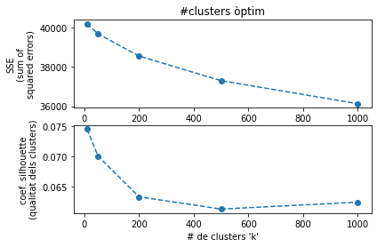

```python
%%time
seed=88
# compare a broad range of ks to start
ks = [10, 50, 200, 500, 1000]

# track a couple of metrics
sil_scores = []
inertias = []

# fit the models, save the evaluation metrics from each run
for k in ks:
    time_start = time.time()
    logging.warning('Aplicant el model per {} clusters'.format(k))
    model = KMeans(n_clusters=k, n_jobs=-1, random_state=seed)
    model.fit(bio_matrix)
    labels = model.labels_
    sil_scores.append(silhouette_score(bio_matrix, labels))
    inertias.append(model.inertia_)
    temps=(time.time()-time_start)/60
    logging.warning('Model finalitzat per {} clusters. Temps: {} min. {} segs.'. \
                    format(k, \
                           int(temps) if temps>0 else 0, \
                           int((temps-int(temps))*60)))

# plot the quality metrics for inspection
fig, ax = plt.subplots(2, 1, sharex=True)

plt.subplot(211)
plt.plot(ks, inertias, 'o--')
plt.ylabel('SSE\n(sum of\nsquared errors)')
plt.title('#clusters òptim')

plt.subplot(212)
plt.plot(ks, sil_scores, 'o--')
plt.ylabel('coef. silhouette\n(qualitat dels clusters)')
plt.xlabel("# de clusters 'k'")
plt.savefig("kmeans_search_k2.jpg",format='jpg',bbox_inches='tight')
```

La gràfica de la prova del colze no ens proporciona cap pista sobre el nombre de clusters òptim, perque no es deixa de redueir l'error a partir d'un valor de **k**. Per seguir analitzant, tot i que no tenim un paràmetre **k**, per al nombre de clústers realment bo, prenem el valor de 200, com acceptable, per què la qualitat dels clusters a partir d'aquest valor no millora.

## K=200

```python
k_optim = 200
seed=88
X_Norm = preprocessing.normalize(matriu_tfidf)
time_start = time.time()
logging.warning('Aplicant el model per {} clusters'.format(k_optim))
km_model = KMeans(n_clusters=k_optim, n_jobs=-1, random_state=seed)
km_model.fit(X_Norm)
temps=(time.time()-time_start)/60
logging.warning('Model finalitzat per {} clusters. Temps: {} min. {} segs.'. \
                format(k_optim, \
                       int(temps) if temps>0 else 0, \
                       int((temps-int(temps))*60)))
```

```
WARNING:root:Aplicant el model per 200 clusters
WARNING:root:Model finalitzat per 200 clusters. Temps: 4 min. 37 segs.
```

```
Nombre d'usuaris en el clúster més gran: 31356
```

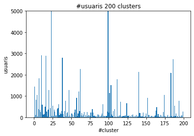

```python
plt.bar(range(len(set(km_model.labels_))), np.bincount(km_model.labels_))
plt.ylabel('usuaris')
plt.xlabel('#cluster')
plt.title('#usuaris {} clusters'.format(k_optim));

# L'eix y queda tallat, per veure el detall de la resta de la gràfic<
plt.ylim(0,5000)
print("Nombre d'usuaris en el clúster més gran:",max(np.bincount(km_model.labels_)))
```

Si volem saber donat un model calculat, quins tokens estan més propers als centroides del clúster als que pertanyen, tindrem les paraules més representatives del clúster. Una funció potser **tokens_mes_propers**:

```python
def tokens_mes_propers(model, vectorizer, topk=10):
    """
    Text representation of the top-k most
    important features in our fit model and vectorizer.

    model: model de sklearn escollit.
    vectorizer: sklearn vectorizer
    topk: k numbers of words to get per cluster

    """
    # Podem usar diferents models
    m_name = model.__class__.__name__
    features = vectorizer.get_feature_names()

    if m_name is 'KMeans':
        relevant_labels = list(set(model.labels_))
        centroids = model.cluster_centers_.argsort()[:,::-1]
        for this_label in relevant_labels:
            print('Cluster {}:'.format(this_label), end='')
            for ind in centroids[this_label, :topk]:
                print(' {}'.format(features[ind]), end='')
            print()
    elif m_name is 'HDBSCAN':
        # ignore noise labels
        relevant_labels = [ x for x in set(model.labels_) if x >= 0 ]
        for this_label in relevant_labels:
            matching_rows = np.where(hdbs.labels_ == this_label)[0]
            coeff_sums = np.sum(bio_matrix[matching_rows], axis=0).A1
            sorted_coeff_idxs = np.argsort(coeff_sums)[::-1]
            print('Cluster {}: '.format(this_label), end='')
            for idx in sorted_coeff_idxs[:topk]:
                print('{} '.format(features[idx]), end='')
            print()

    else:
        raise NotImplementedError('Només són possibles els KMeans i HDBSCAN.')
```

```python
tokens_mes_propers(km_model, tfidf_vect, topk=15)
```

```
Cluster 0: lang cornel sar artic cas fract fra fr fq fpi fpa foxtrot fox fowl fous
Cluster 1: affect mil peopl diseas rar liv today europ pop suff thousand fo day many world
Cluster 2: sid alway much peopl paty teamwork vál ev feel bit persev on wrestl posit real
Cluster 3: today rarest rais year aw liv peopl day ded rar diseas famy leap also unit
Cluster 4: also rar diseas day today support febru paty poetry obvy rudy permit ye confid balear
Cluster 5: ens govern must next everyon access serv condit support liv rar uachtaráin ára en speak
Cluster 6: research brak fract healthc invest system diagnos fous fra fr fq fpi fpa foxtrot fox
Cluster 7: stress day tel chang story want lif today saw fpi foxtrot fpa 𝟮𝟵 fq fra
Cluster 8: convert tt celebr help world us today day fpa fpi fr fq fox fra fract
Cluster 9: term ref weird nam tak diseas rar today refer février fourteen fract fra fr fq
Cluster 10: sist broth integr opportun il off car togeth research us enjoy assist eq might soc
Cluster 11: rememb day today import diseas rar santiago investig help febru fel hist pair among focus
Cluster 12: partn fac sci com challeng commun many togeth tackl del solv innov work fourny franç
Cluster 13: few affect rar diseas consid peopl europ defin disord condit folk mean today us person
Cluster 14: impl fasg collabor febru celebr world diseas nurs day tomorrow rar rara th folkl fox
Cluster 15: admir determin ask ded friend pleas shar founded foundationtofighthabc fought fragil frag foun fract fra
Cluster 16: support thank rar diseas famy commit show help research peopl paty today us commun affect
Cluster 17: febru imply collabor nurs celebr world day diseas rar rara th tomorrow collab fowl fr
Cluster 18: spent imp anoth answ plan look ev diagnos tre many today day academ fed industry
Cluster 19: disp dob poss oft receiv expery cur tre affect peopl diseas rar manupalo must fus
Cluster 20: lik would rar today diseas day support feel paty work peopl suff look liv know
Cluster 21: shar we word spread th febru excit incred journey long celebr lov week video paty
Cluster 22: bo across let around join togeth mil liv world peopl diseas rar bord rais aw
Cluster 23: today paty rar day research work help diseas year us diagnos liv ev peopl tre
Cluster 24: investig involv commit improv help diseas rar fra fr fq fourny fpa foxtrot fox fowl
Cluster 25: macroglobul carl waldenström ago serv hon lik diagnos year peopl wm macroglobulinem fierc form advoc
Cluster 26: research contract enco project diseas rar fract fra frag fragil fr fq fpi fpa foxtrot
Cluster 27: friday day nin org adv reg research febru feb join ev comply op intern celebr
Cluster 28: mark spain suff mil world peopl today day almost littl on diseas rar every frank
Cluster 29: solid intern suff famy peopl day paty fowl fourny fourteen fous foxtrot fox fountain fpa
Cluster 30: microsom hemifac moth daught rememb affect today afflict foxtrot frag fract fra fr fq fpi
Cluster 31: cit eu mean diseas rar many affect mil liv speranzaeurope world today clear day lack
Cluster 32: sm queen crec presid campaign ev off hop day esp wait esperanz act heart cntigo
Cluster 33: liv mil around peopl world diseas rar day support show today febru famy know rais
Cluster 34: contag cours non today fox fragile fragil frag fract fra fr fq fpi fpa foxtrot
Cluster 35: largest numb equ country downlo rd know liv world peopl diseas rar third pop eq
Cluster 36: lean tow pis bright shin hap mak thank enlight febru fq fr fox fpi fpa
Cluster 37: help bpan smal could morg sav don cur pleas lif us ht diseas see daught
Cluster 38: day world diseas today febru rar celebr tomorrow us commem work particip import hasht help
Cluster 39: thi got dis known oth talk condit many today tip top expect peopl think nat
```

[output cut: 145 more lines]

```
Cluster 185: adv also learn every work rais aw today day duk udn affect am estim research
Cluster 186: rais aw rar diseas today day help paty let impact liv join febru field shar
Cluster 187: buenosdia beso viern goe weekend thing celebr world today day diseas rar friday franky fr
Cluster 188: last day febru year aw world rais celebr rar diseas sint every plac tak help
Cluster 189: materno jda vi prev progress diagnos diseas rar fox fous fowl 𝟮𝟵 foxtrot fourny fpa
Cluster 190: right heal protect min must alway pres univers struggle cam rel retransmit jornad left diseas
Cluster 191: biologist extreme mecan cambridg describ univers lead study op four foxtrot fragil frag fract fra
Cluster 192: investy cant import peopl today day rar per suff uncommon dr diseas research foundat fox
Cluster 193: dog cat acknowledg hum would lik liv peopl today rar diseas esp aim prev tre
Cluster 194: happy day rar diseas win best help lif us staff famy today aw nord fellow
Cluster 195: ix jornad org occas adv friday yet sign investig day celebr workshop pil welcom pres
Cluster 196: microbiom innap fibromyalg handl team med diseas rar man founders foundationtofighthabc fragil foundat frag fract
Cluster 197: die deserv approv child tre discov termin gift win lif help paty us diseas fr
Cluster 198: wil investig would cal diseas rar busy without long feel fract fra fr fq fpi
Cluster 199: latest thank dai new kiziukiewicz stevy diseas rar strongly blee journ blog eliasctm byrd hawai
```

```python
# Guardant el model de 200 clusters en un fitxer a disc.
fitxer = open('Kmeans_200.pkl', 'wb')

# Guardar el model a disc (dump):
pickle.dump(km_model, fitxer)

# Tancant el fitxer.
file.close()
```

```python
# Recuperació del model guardat a disc:
file = open('Kmeans_200.pkl', 'rb')

# Apertura i càrrega del model des de disc.
km_model1 = pickle.load(file)

# Tancant el fitxer.
file.close()
```

## k=15

```python
k_optim = 15
time_start = time.time()
logging.warning('Aplicant el model per {} clusters'.format(k_optim))
km_model15 = KMeans(n_clusters=k_optim, n_jobs=-1, random_state=seed)
km_model15.fit(X_Norm)
temps=(time.time()-time_start)/60
logging.warning('Model finalitzat per {} clusters. Temps: {} min. {} segs.'. \
                format(k_optim, \
                       int(temps) if temps>0 else 0, \
                       int((temps-int(temps))*60)))
```

```
WARNING:root:Aplicant el model per 15 clusters
WARNING:root:Model finalitzat per 15 clusters. Temps: 2 min. 18 segs.
```

```python
tokens_mes_propers(km_model15, tfidf_vect, topk=8)
```

```
Cluster 0: stress day tel chang story want lif today
Cluster 1: today rar diseas paty help us research peopl
Cluster 2: today year rarest peopl rais aw liv carl
Cluster 3: research brak fract healthc invest system diagnos fous
Cluster 4: support show rar today paty diseas famy peopl
Cluster 5: rar strong proud many show tallest duba lit
Cluster 6: thank support much latest us mak rar day
Cluster 7: commun rar diseas support day show com partn
Cluster 8: know rar diseas ex vivid real deal wel
Cluster 9: affect mil peopl diseas spain rar uncommon eu
Cluster 10: sist broth integr opportun il off car togeth
Cluster 11: day world today celebr crec campaign rar diseas
Cluster 12: febru day world diseas rar celebr th tomorrow
Cluster 13: rar diseas peopl liv day mil today aw
Cluster 14: admir determin ask ded friend pleas shar founded
```

```python
# Guardant el model de quinze clusters en un fitxer a disc.
fitxer = open('Kmeans_15.pkl', 'wb')

# Guardar el model a disc (dump):
pickle.dump(km_model15, fitxer)

# Tancant el fitxer.
file.close()
```

## K=6

```python
k_optim = 6
time_start = time.time()
logging.warning('Aplicant el model per {} clusters'.format(k_optim))
km_model6 = KMeans(n_clusters=k_optim, n_jobs=-1, random_state=seed)
km_model6.fit(X_Norm)
temps=(time.time()-time_start)/60
logging.warning('Model finalitzat per {} clusters. Temps: {} min. {} segs.'. \
                format(k_optim, \
                       int(temps) if temps>0 else 0, \
                       int((temps-int(temps))*60)))
```

```
WARNING:root:Aplicant el model per 6 clusters
WARNING:root:Model finalitzat per 6 clusters. Temps: 2 min. 49 segs.
```

```python
t6=tokens_mes_propers(km_model6, tfidf_vect, topk=8)
```

```
Cluster 0: stress day tel chang story want lif today
Cluster 1: rar thank diseas today support research paty us
Cluster 2: rar diseas peopl mil liv affect day many
Cluster 3: day today world aw peopl rais rarest year
Cluster 4: sist broth integr opportun il off car togeth
Cluster 5: febru day world celebr diseas rar th today
```

```python
# Guardant el model de 6 clusters en un fitxer a disc.
fitxer = open('Kmeans_6.pkl', 'wb')

# Guardar el model a disc (dump):
pickle.dump(km_model6, fitxer)

# Tancant el fitxer.
file.close()
```

```python
df_kmeans_last_200=pd.DataFrame({'id':tuits._id,'text':tuits.text, 'text_norm':tuits.text_norm, \
                                 'autor':tuits.autor,'km_model200':km_model.labels_})
df_kmeans_last_200.shape
```

```
(98433, 5)
```

```python
df_kmeans_last_200.to_excel("Clusters_cosinus_k200.xlsx", index=0)
```

## DBSCAN

```python
import numpy as np

# Algorisme DBSCAN (clustering per densitat)
from sklearn.cluster import DBSCAN

# Preprocessing per normalitzar el dataset
from sklearn.preprocessing import StandardScaler
```

```python
# generem l'estructura de dades del model DBSCAN
Xz = matriu_tfidf[:,0:100]
```

```python
# Configurem paràmetres eps i min_spl
eps=0.001;  min_spl=100;  inc_eps=0.05;
```

```python
db = DBSCAN(eps=eps, min_samples=min_spl, algorithm='ball_tree', metric=['cosine']).fit(Xz)
#DBSCAN(eps=eps, min_samples=ms, algorithm='ball_tree', metric='haversine').fit(np.radians(coords))
```

```python
db
```

[output not shown]

```python
import sklearn
sorted(sklearn.neighbors.VALID_METRICS_SPARSE['brute'])
```

```
['cityblock', 'cosine', 'euclidean', 'l1', 'l2', 'manhattan', 'precomputed']
```